# Does the gender and ethnicity of New College students influence their experience with math classes?

12/12/2017

## Goals of the Survey

Measure the following with respect to students from underrepresented groups in math courses at NCF:

- Belonging uncertainty
- Confidence levels
- Stereotype threat

## Background Information

- New College has 861 students (as of Fall 2016) and the survey had a total of 264 responses which are all complete.
- Data was de-identified before being given to us. No IRB approval, since results are not being published.
- Responders were 60% female, 28.3% male, and 11.7% non-binary.

## Data and Cleaning

- **Likert item responses**
  - Ordinal data: ordered but not translatable to continuous form
  - Strongly Disagree…Strongly Agree
- **Gender**
  - Male
  - Non-male
- **Ethnicity**
  - Non-hispanic white
  - Minorty
- **AOC**
  - STEM
  - Non-STEM

## Issues

- **Small Sample Size**: only ~260 responses
- **Non-response Bias**: the phenomenon that the required information is not obtained from the people selected in the sample
- **Social Desirability and Acquiescence Bias**: students may avoid using extreme response categories out of a desire of being perceived as having extremist views and may tend to aree with statements as presented

## Anxiety Level

### Visualize Responses by Gender

- "Compared to other subjects, do you feel more or less anxiety in mathematics classes?"

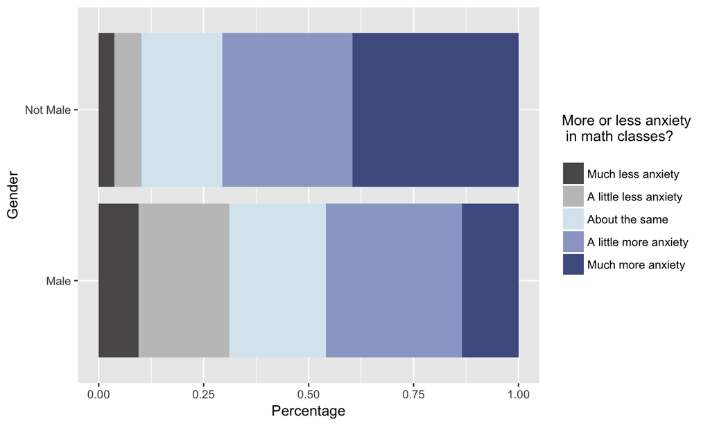

## Anxiety Level

### Visualize Responses by Race/Ethnicity

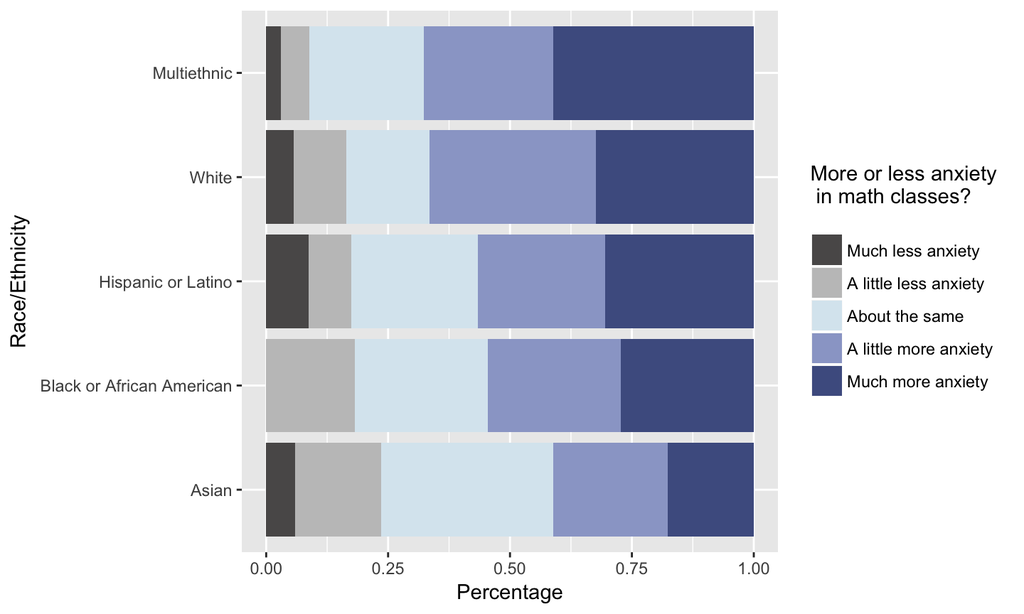

## Anxiety Level

### Analysis

- Ordinal Logistic Regression
  - The confidence intervals for both `gender` and `is_stem` do not include 0; `is_minority` and `year` do: There is evidence to support that a student's gender and AOC are statistically significant predictors of their reported anxiety levels.
- Mann-Whitney U Test
  - p-value of 2.313 x 10<sup>-6</sup> allows the rejection of the null hypothesis. Conclude that the responses from male and non-male students are from different distributions.
- Chi-Squared Test of Association
  - Anxiety level responses are dependent on a student's masculinity (self-id male/non-male). p = 3.354 x 10<sup>-05</sup>

## Confidence Level

### Visualize Responses by Gender

- "How would you rate your mathematical ability compared to the student population at New College?"

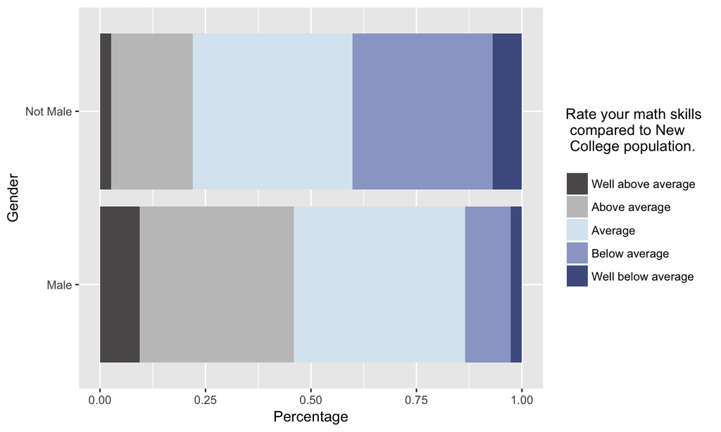

## Confidence Level

### Visualize Responses by Race/Ethnicity

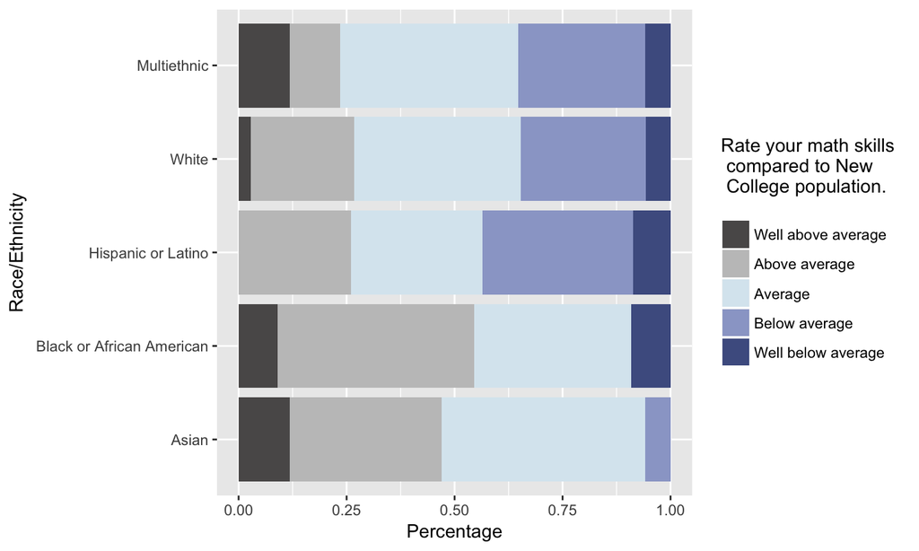

## Confidence Level

### Analysis

- Ordinal Logistic Regression
  - The confidence intervals for `gender`, `year`, and `is_stem` do not include 0; `is_minority` does: There is evidence to support that a student's gender, year, and AOC are statistically significant predictors of their reported confidence levels in mathematics classes.
- Mann-Whitney U Test
  - p-value of 2.278 x 10<sup>-6</sup> allows the rejection of the null hypothesis. Conclude that the responses from male and non-male students are from different distributions.
- Chi-Squared Test of Association
  - Students' self-reported masculinity (self-ID male/non-male) and confidence levels are associated/dependent. p = 1.604 x 10<sup>-5</sup>.

## Stereotype Threat

### Visualize Responses by Gender

"How often are you concerned that your performance in math will confirm a negative stereotype about you?"

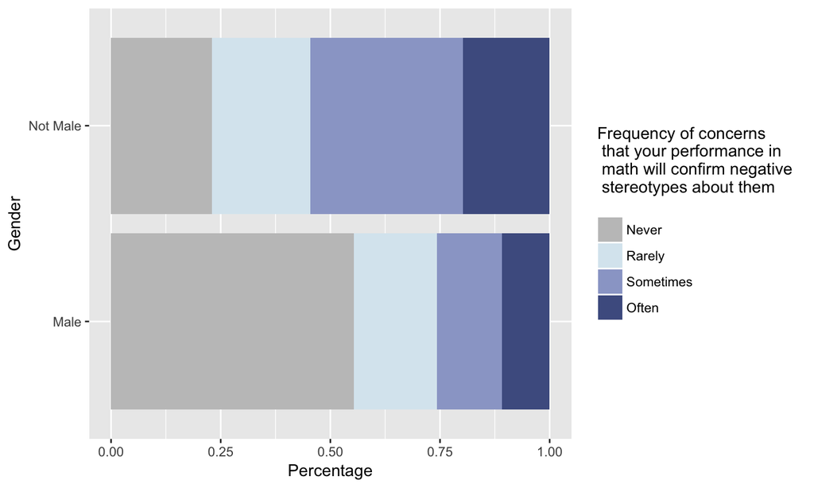

## Stereotype Threat

### Visualize Responses by Race/Ethnicity

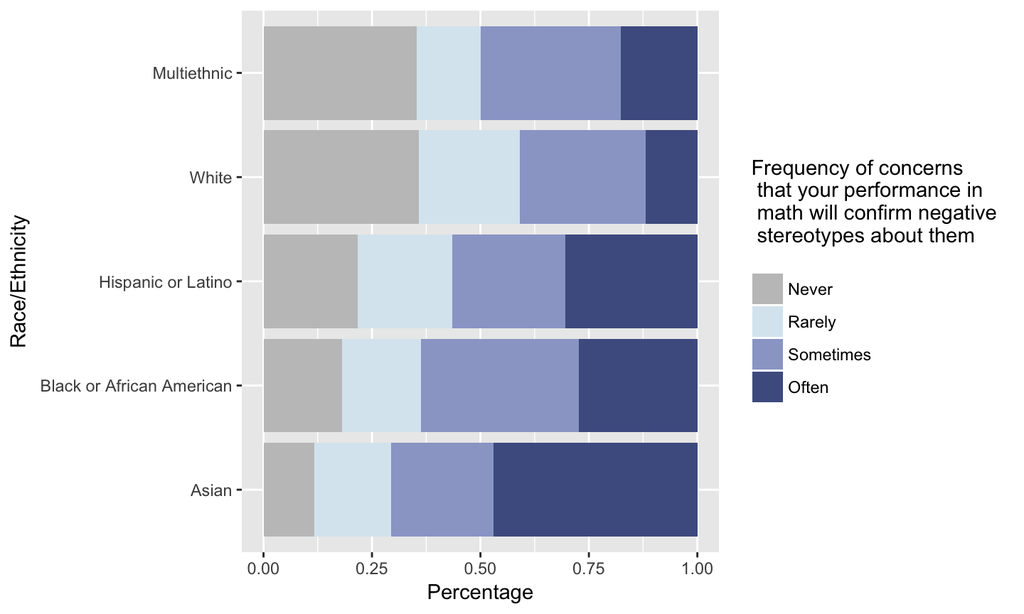